# 🗳️ Cost of Living & Marginal Seats in Victoria: A Data-Driven Political Insight

A personal project exploring the intersection of federal election results, housing costs, and census data in Victoria, Australia.

Created by HARDIK AJAY DIXIT | Data Analyst & R Enthusiast

2025-03-25

**🔍 Project Overview**

This project is a personal exploration of how cost of living indicators (like rent and mortgage payments) intersect with marginal seats from the 2022 Australian Federal Election, focusing on Victoria.

I was curious: Are voters in marginal electorates more vulnerable to financial stress? To investigate this, I combined election result data with census data from 2016 and 2021, visualizing key metrics geographically using R.

# 1 🧩 Identifying Marginal Seats in Victoria

## 1.1 Load and filter election results to find marginal seats won with <56% of preference votes.

```r
election_data <- read.csv("data/HouseDopByDivisionDownload-27966.csv", skip = 1)


# Filter to only include seats in Victoria
Marginal_seats <- election_data %>%
  filter(StateAb == "VIC") %>%

# Filter to only Preference Count
  filter(CalculationType == "Preference Percent" & Elected == "Y") %>%
      group_by(DivisionNm) %>%

# Filter Marginal winning seats less than 56%
  filter(CountNumber == max(CountNumber))
Marginal_seats <- Marginal_seats %>% select(StateAb,DivisionNm,CountNumber,Surname,GivenNm,PartyNm, PartyAb,CalculationType, CalculationValue) %>%
  mutate(marginal = ifelse(CalculationValue < 56 , "Y" , "N")) %>% filter(marginal == "Y") %>%
  mutate(DivisionNm=toupper(DivisionNm))%>% arrange(DivisionNm)

Marginal_seats
```

```
## # A tibble: 11 × 10
## # Groups:   DivisionNm [11]
##    StateAb DivisionNm CountNumber Surname      GivenNm  PartyNm          PartyAb
##    <chr>   <chr>            <int> <chr>        <chr>    <chr>            <chr>
##  1 VIC     ASTON                5 TUDGE        Alan     Liberal          LP
##  2 VIC     CASEY                9 VIOLI        Aaron    Liberal          LP
##  3 VIC     DEAKIN               8 SUKKAR       Michael  Liberal          LP
##  4 VIC     GOLDSTEIN            7 DANIEL       Zoe      Independent      IND
##  5 VIC     HIGGINS              6 ANANDA-RAJAH Michelle Australian Labo… ALP
##  6 VIC     KOOYONG              9 RYAN         Monique  Independent      IND
##  7 VIC     MCEWEN               5 MITCHELL     Rob      Australian Labo… ALP
##  8 VIC     MENZIES              5 WOLAHAN      Keith    Liberal          LP
##  9 VIC     MONASH               6 BROADBENT    Russell  Liberal          LP
## 10 VIC     NICHOLLS             9 BIRRELL      Sam      The Nationals    NP
## 11 VIC     WANNON               6 TEHAN        Dan      Liberal          LP
## # ℹ 3 more variables: CalculationType <chr>, CalculationValue <dbl>,
## #   marginal <chr>
```

## 1.2 Load electoral boundaries to prepare for visualisation

```r
library(sf)
vic_map <- read_sf(here::here("data/vic-july-2021-esri/E_VIC21_region.shp"), quiet = TRUE) %>%
  rename(DivisionNm = Elect_div) %>%
  mutate(DivisionNm = toupper(DivisionNm))
   # to match up with election data
vic_map <- st_zm(vic_map)
```

## 1.3 Set political party colours

```r
# define the political colors (feel free to change)
party_colors <- c("ALP" = "#DE3533", "LNP" = "#ADD8E6",
                  "KAP" = "#8B0000", "GRN" = "#10C25B",
                  "GVIC" = "#10C25B", "XEN" = "#ff6300",
                  "LP" = "#0047AB", "NP" = "#0a9cca",
                  "IND" = "#000000")
```

## 1.4 Map the marginal seat winners in Victoria

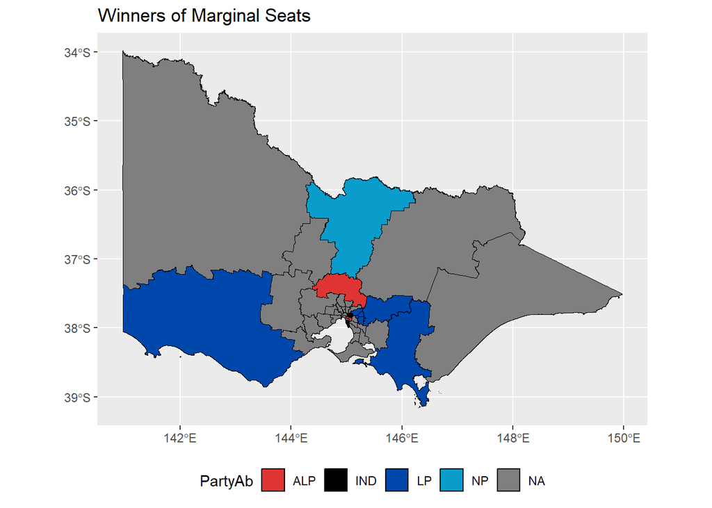

```r
ggplot(left_join(vic_map, Marginal_seats, by = "DivisionNm")) +
  geom_sf(aes(geometry = geometry, fill = PartyAb), color = "black", size = 1.8) +
  coord_sf(xlim = c(140.9617, 149.9763), ylim = c(-39.15919, -33.98043)) +
  scale_fill_manual(values = party_colors) +
  ggtitle("Winners of Marginal Seats") +
  theme(legend.position = "bottom") +
  guides(fill = guide_legend(nrow = 1))
```

## 1.5 Enrolment Data

```r
enrolment_div <- read_csv("data/GeneralEnrolmentByDivisionDownload-27966.csv", skip = 1)

enrolment_div %>% mutate(DivisionNm = toupper(DivisionNm)) %>%
left_join(enrolment_div ,
          by = "DivisionNm")
```

```
## # A tibble: 151 × 21
##    DivisionID.x DivisionNm StateAb.x CloseOfRollsEnrolment.x
##           <dbl> <chr>      <chr>                       <dbl>
##  1          179 ADELAIDE   SA                         130151
##  2          197 ASTON      VIC                        109826
##  3          198 BALLARAT   VIC                        110704
##  4          103 BANKS      NSW                        107786
##  5          180 BARKER     SA                         123518
##  6          104 BARTON     NSW                        110484
##  7          192 BASS       TAS                         79433
##  8          318 BEAN       ACT                        109557
##  9          200 BENDIGO    VIC                        112498
## 10          105 BENNELONG  NSW                        115030
## # ℹ 141 more rows
## # ℹ 17 more variables: NotebookRollAdditions.x <dbl>,
## #   NotebookRollDeletions.x <dbl>, ReinstatementsPostal.x <dbl>,
## #   ReinstatementsPrePoll.x <dbl>, ReinstatementsAbsent.x <dbl>,
## #   ReinstatementsProvisional.x <dbl>, Enrolment.x <dbl>, DivisionID.y <dbl>,
## #   StateAb.y <chr>, CloseOfRollsEnrolment.y <dbl>,
## #   NotebookRollAdditions.y <dbl>, NotebookRollDeletions.y <dbl>, …
```

```r
enrolment_div %>%
  select(1,2,3,11)
```

```
## # A tibble: 151 × 4
##    DivisionID DivisionNm StateAb Enrolment
##         <dbl> <chr>      <chr>       <dbl>
##  1        179 Adelaide   SA         129960
##  2        197 Aston      VIC        109705
##  3        198 Ballarat   VIC        110570
##  4        103 Banks      NSW        107700
##  5        180 Barker     SA         123326
##  6        104 Barton     NSW        110371
##  7        192 Bass       TAS         79322
##  8        318 Bean       ACT        109432
##  9        200 Bendigo    VIC        112354
## 10        105 Bennelong  NSW        114942
## # ℹ 141 more rows
```

# 2 🏠 Comparing Housing and Income Data in 2016 vs 2021

## 2.1 Load Census Data

```r
# Load the census2016 dataset
SA1_2016 <- here::here("data/Geopackage_2016_EIUWA_for_VIC/census2016_eiuwa_vic_short.gpkg")
census_2016 <- read_sf(SA1_2016, layer = "census2016_eiuwa_vic_sa1_short")



# Load the G02 dataset
SA1_2021 <- here::here("data/Geopackage_2021_G02_VIC_GDA94/G02_VIC_GDA94.gpkg")
census_2021 <- read_sf(SA1_2021, layer = "G02_SA1_2021_VIC")
```

- 🔎 Limitations:

There are 14073 and 15482 observations in the data due to which comparison is not possible.

The 2016 and 2021 datasets use different geographical identifiers, making direct comparisons at SA1 level tricky.

## 2.2 Visualise Weekly Rent

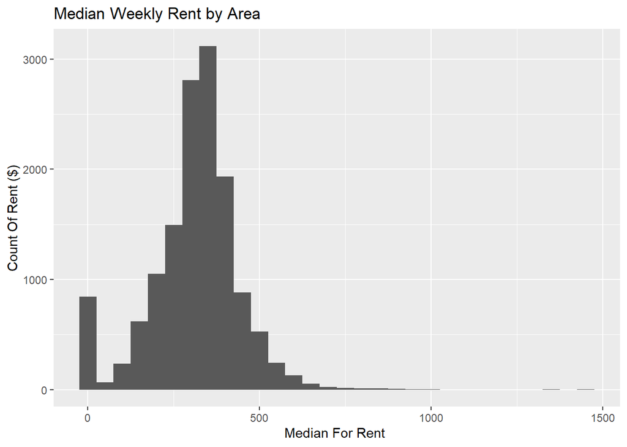

```r
library(ggplot2)
census_2016 %>%
  ggplot(aes(x = Median_rent_weekly)) +
  geom_histogram() +
  ggtitle("Median Weekly Rent by Area") +
  xlab("Median For Rent ") +
  ylab("Count Of Rent ($)")
```

```r
summary(census_2016$Median_rent_weekly)
```

```
##    Min. 1st Qu.  Median    Mean 3rd Qu.    Max.
##     0.0   250.0   324.0   311.7   381.0  1450.0
```

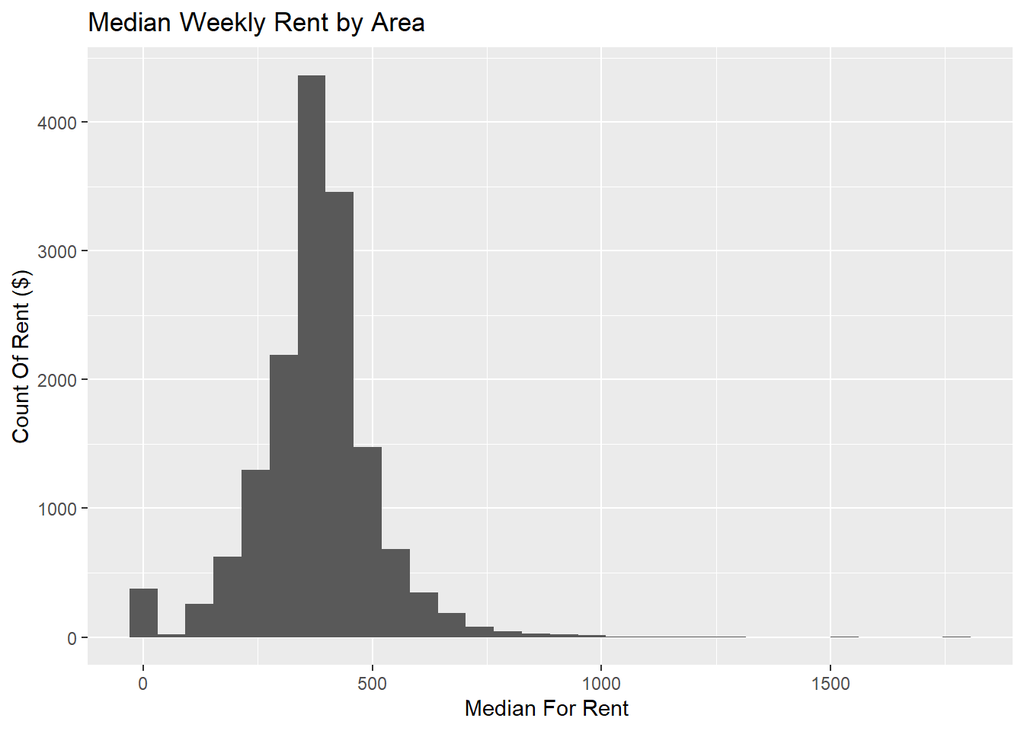

```r
library(ggplot2)
census_2021 %>%
  ggplot(aes(x = Median_rent_weekly)) +
  geom_histogram() +
  ggtitle("Median Weekly Rent by Area") +
  xlab("Median For Rent ") +
  ylab("Count Of Rent ($)")
```

```r
summary(census_2021$Median_rent_weekly)
```

```
##    Min. 1st Qu.  Median    Mean 3rd Qu.    Max.
##     0.0   317.0   380.0   375.6   435.0  1775.0
```

## 2.3 Visualise Weekly Household Income

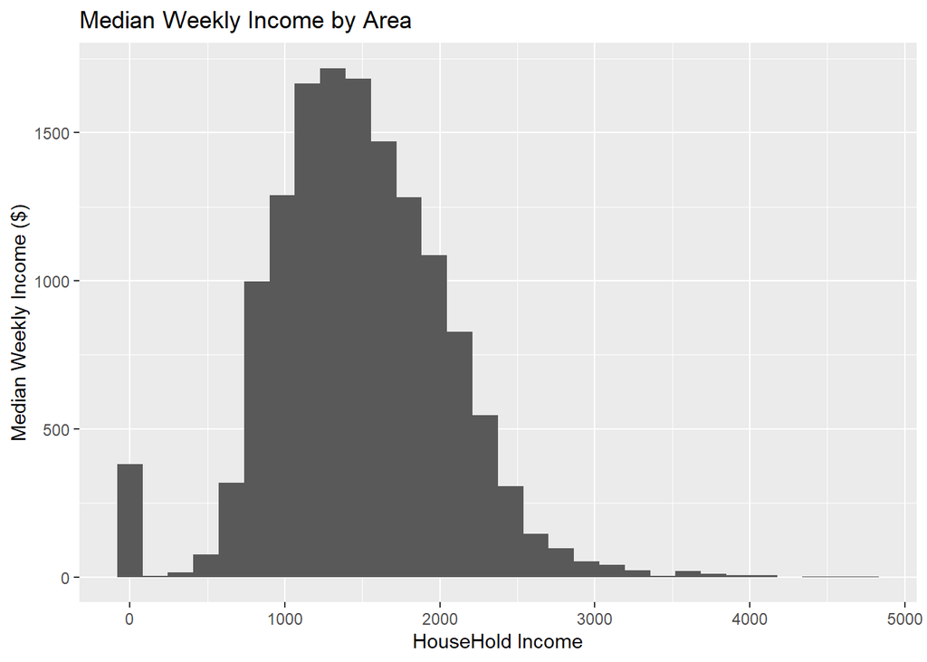

```r
census_2016 %>%
  ggplot(aes(x = Median_tot_hhd_inc_weekly))+
  geom_histogram() +
  ggtitle("Median Weekly Income by Area") +
  xlab("HouseHold Income") +
  ylab("Median Weekly Income ($)")
```

```r
summary(census_2016$Median_tot_hhd_inc_weekly)
```

```
##    Min. 1st Qu.  Median    Mean 3rd Qu.    Max.
##       0    1112    1447    1479    1836    4749
```

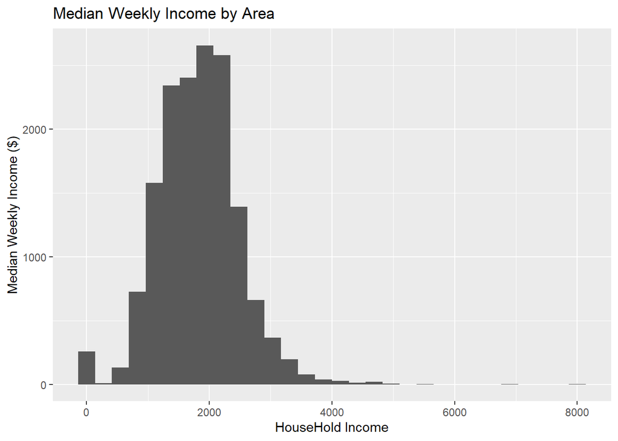

```r
census_2021 %>%
  ggplot(aes(x = Median_tot_hhd_inc_weekly)) +
  geom_histogram() +
  ggtitle("Median Weekly Income by Area ") +
  xlab("HouseHold Income") +
  ylab("Median Weekly Income ($)")
```

```r
summary(census_2021$Median_tot_hhd_inc_weekly)
```

```
##    Min. 1st Qu.  Median    Mean 3rd Qu.    Max.
##       0    1385    1823    1822    2220    8000
```

### 2.3.1 🔎 Limitations of Using 30% Rule as Stress Indicator

Lack of precision: Using the average housing cost and 30% of the average household income as proxy for mortgage/rental stress can only give a ballpark figure. Individual circumstances, such as the number of dependents, work status, and other elements that influence household income and expenses are not taken into consideration.

Regional variations: Housing expenses can vary widely from one place to another. Victoria’s diverse housing markets might not be adequately represented by a single criterion applied to the entire state.

Data gaps: The census does not fully account for costs associated with dwelling, such as utilities, property taxes, and maintenance costs.As such, comparing the median amount of money spent on housing to 30% of the median household income may not give a complete picture of the financial stress faced by households.

Changes over time: Due to changes in the housing market and the wider economy over time, comparing the median amount spent on housing in 2016 and 2021 and the 30% criterion may not be appropriate. For instance, changes in interest rates, rental costs, and household earnings over time may all have an impact on the percentage of households that are stressed out about their mortgage or rent.

# 3 📍Mapping Cost of Living Stress by Electorate (Personal Spatial Analysis)

In this section, I explored how spatial divisions (SA1 regions) align with federal electorates in Victoria. My main goal was to visualise and compare cost of living indicators between marginal and non-marginal seats using Census 2021 data.

## 3.1 🧭 Mapping SA1s to Divisions

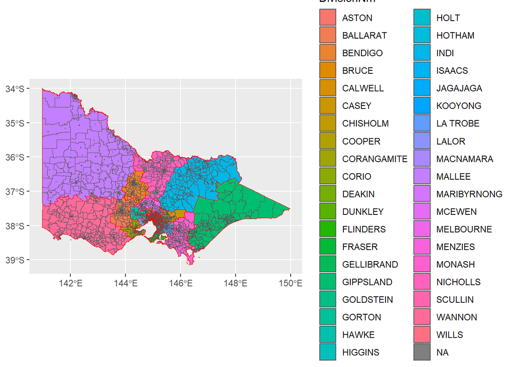

```r
joined_map_2016 <- st_join(st_centroid(census_2016), vic_map) %>%
  st_join(census_2016 %>% select(sa1_7digitcode_2016), .)

ggplot(data = joined_map_2016) +
   geom_sf(aes(geometry = geom, fill = DivisionNm)) +
  geom_sf(data = vic_map,
          aes(geometry = geometry), col = "red", fill = "transparent")
```

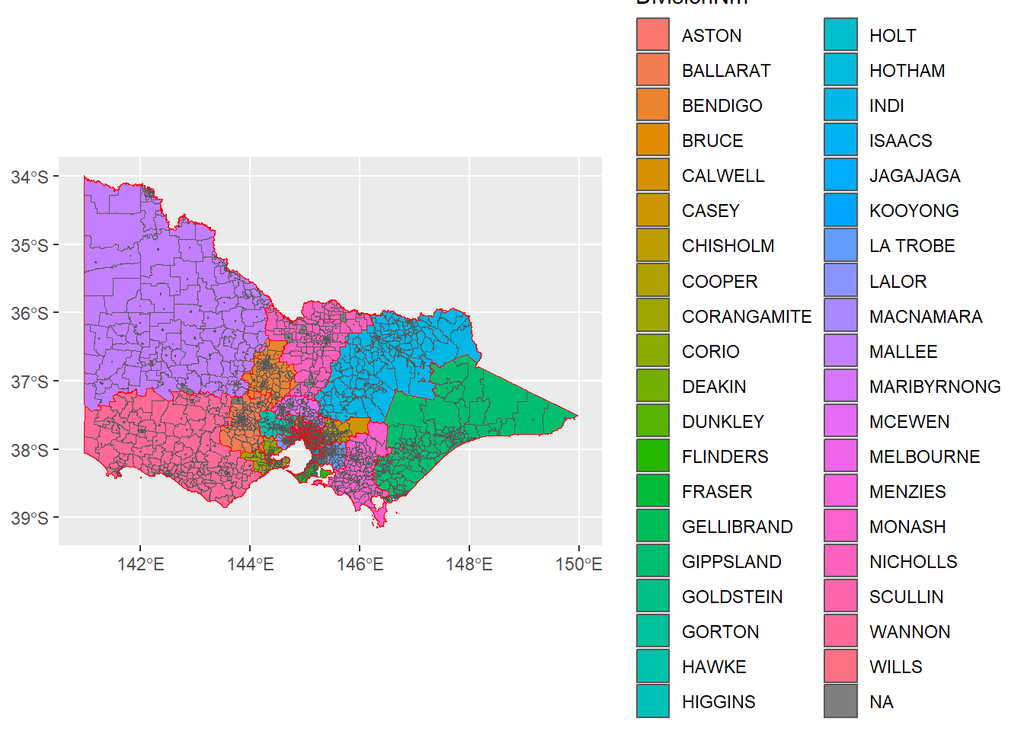

```r
joined_map_2021 <- st_join(st_centroid(census_2021), vic_map) %>%
  st_join(census_2021 %>% select(SA1_CODE_2021), .)

ggplot(data = joined_map_2021) +
   geom_sf(aes(geometry = geom, fill = DivisionNm)) +
  geom_sf(data = vic_map,
          aes(geometry = geometry), col = "red", fill = "transparent")
```

```r
SA1_Melb_2016 <- joined_map_2016 %>%
  filter(DivisionNm == "MELBOURNE")

SA1_Melb_2021 <- joined_map_2021 %>%
  filter(DivisionNm == "MELBOURNE")
```

The number of SA1 Regions in Melbourne in 2016 are 339 and in 2021 are 461.

## 3.2 📊 Calculating Average Cost Indicators for Melbourne

```r
Mean_Melb <- SA1_Melb_2021%>%
  summarise(Mean_mortgage_repay_monthly_2021 = mean(Median_mortgage_repay_monthly),
            Mean_rent_weekly_2021 = mean(Median_rent_weekly),
            Mean_tot_hhd_inc_weekly_2021 = mean(Median_tot_hhd_inc_weekly))
```

📌 Process Recap:

- Loaded both 2016 and 2021 GeoPackage datasets.
- Filtered Victoria’s data to focus on Melbourne’s SA1s.
- Calculated the mean for mortgage, rent, and household income indicators across these areas.

⚠️ Note: These means are derived from median values per SA1, not raw income or housing payments. As such, it’s an approximation for high-level comparison only.

## 3.3 📍 Visualising Cost of Living in Marginal vs Non-Marginal

[output not shown]

I calculated cost of living ratios — rent/income and mortgage/income — across marginal and non-marginal electorates to explore spatial inequalities.

```r
marginal_joined_map_2021 <- joined_map_2021 %>%
  filter(DivisionNm %in% c("ASTON", "CASEY", "DEAKIN", "GOLDSTEIN", "HIGGINS", "KOOYONG", "MCEWEN", "MENZIES", "MONASH", "NICHOLLS", "WANNON"))

costofliving_marginial <- marginal_joined_map_2021 %>%
  mutate(col_rent = (Median_rent_weekly/Median_tot_hhd_inc_weekly),
         col_mortgage = (Median_mortgage_repay_monthly/Median_tot_hhd_inc_weekly))
```

## 3.4 Rent Stress: Marginal Seats

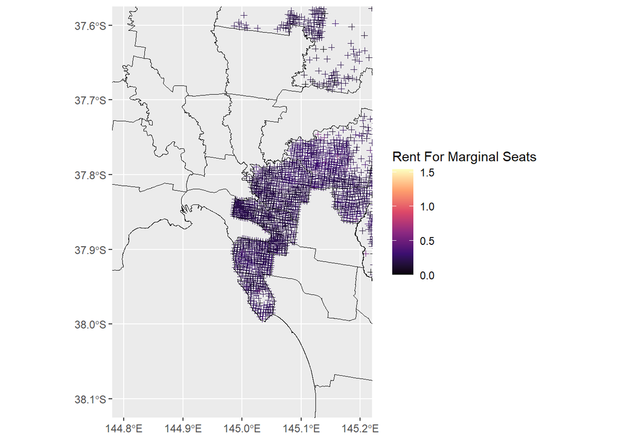

```r
col_rent_map <- costofliving_marginial %>%
   mutate(centroid = st_centroid(geom)) %>%
   filter(Median_age_persons != 0)

ggplot(col_rent_map) +
   geom_sf(aes(geometry = centroid, color = col_rent), shape = 3) +
   geom_sf(data = vic_map, aes(geometry = geometry), fill = "transparent", size = 1.3, color = "black") +
   coord_sf(xlim = c(144.8, 145.2), ylim = c(-38.1, -37.6)) +
   scale_color_viridis_c(name = "Rent For Marginal Seats", option = "magma")
```

```r
nonmarginal_joined_map_2021 <- joined_map_2021 %>%
  filter(!(DivisionNm %in% c("ASTON", "CASEY", "DEAKIN", "GOLDSTEIN", "HIGGINS", "KOOYONG", "MCEWEN", "MENZIES", "MONASH", "NICHOLLS", "WANNON")))

costofliving_nonmarginial <- nonmarginal_joined_map_2021 %>%
  mutate(col_rent = (Median_rent_weekly/Median_tot_hhd_inc_weekly),
         col_mortgage = (Median_mortgage_repay_monthly/Median_tot_hhd_inc_weekly))
```

## 3.5 Rent Stress: Non-Marginal Seats

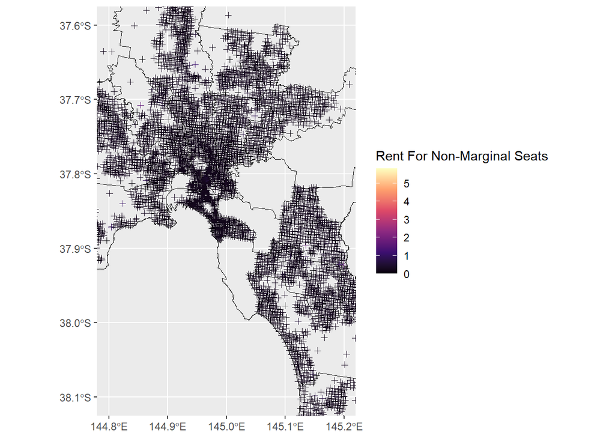

```r
col_rent_map_non <- costofliving_nonmarginial %>%
   mutate(centroid = st_centroid(geom)) %>%
   filter(Median_age_persons != 0)

ggplot(col_rent_map_non) +
   geom_sf(aes(geometry = centroid, color = col_rent), shape = 3) +
   geom_sf(data = vic_map, aes(geometry = geometry), fill = "transparent", size = 1.3, color = "black") +
   coord_sf(xlim = c(144.8, 145.2), ylim = c(-38.1, -37.6)) +
   scale_color_viridis_c(name = "Rent For Non-Marginal Seats", option = "magma")
```

## 3.6 💰 Mortgage Stress: Marginal vs Non-Marginal

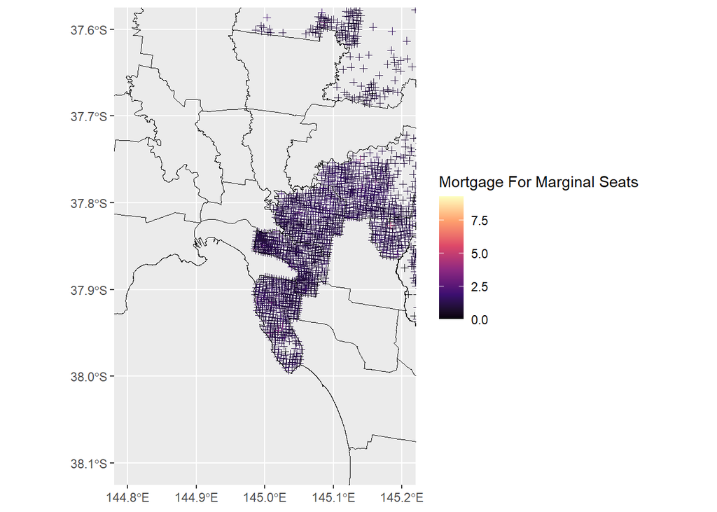

```r
col_mortgage_map <- costofliving_marginial %>%
   mutate(centroid = st_centroid(geom)) %>%
   filter(Median_age_persons != 0)

ggplot(col_mortgage_map) +
   geom_sf(aes(geometry = centroid, color = col_mortgage), shape = 3) +
   geom_sf(data = vic_map, aes(geometry = geometry), fill = "transparent", size = 1.3, color = "black") +
   coord_sf(xlim = c(144.8, 145.2), ylim = c(-38.1, -37.6)) +
   scale_color_viridis_c(name = "Mortgage For Marginal Seats", option = "magma")
```

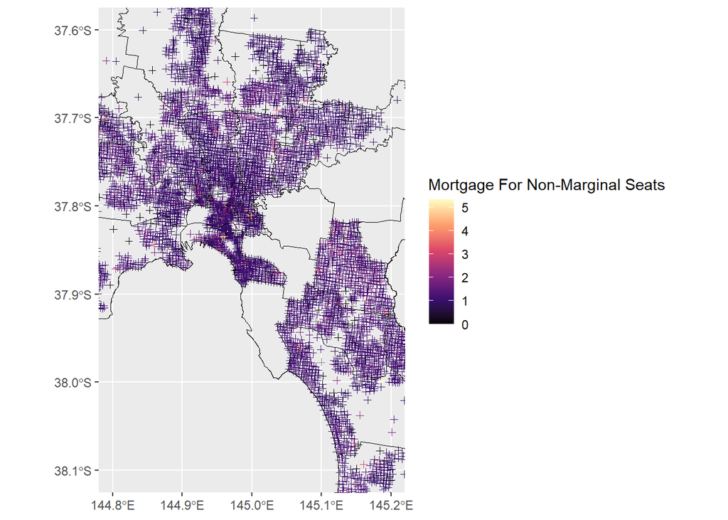

```r
col_mortgage_map_non <- costofliving_nonmarginial %>%
   mutate(centroid = st_centroid(geom)) %>%
   filter(Median_age_persons != 0)

ggplot(col_mortgage_map_non) +
   geom_sf(aes(geometry = centroid, color = col_mortgage), shape = 3) +
   geom_sf(data = vic_map, aes(geometry = geometry), fill = "transparent", size = 1.3, color = "black") +
   coord_sf(xlim = c(144.8, 145.2), ylim = c(-38.1, -37.6)) +
   scale_color_viridis_c(name = "Mortgage For Non-Marginal Seats", option = "magma")
```